# U-TAD - PEDS: Práctica 14 - Técnicas de aprendizaje no supervisado

Rafael Enríquez-Herrador (rafael.enriquez@live.u-tad.com)

17/02/2016

## Análisis de aceites de oliva (III)

Repetir el análisis sobre los mismos datos pero transformados mediante PCA:

1. Reducir la dimensión del conjunto de datos usando PCA (¿cuántas son suficientes?)
2. Crear clústers usando k-medias o k-medioides.

Analizar brevemente los resultados obtenidos.

Cargamos las librerías que utilizaremos:

```r
# install.packages("data.table")
library(data.table)
# install.packages("NbClust")
library(NbClust)
# install.packages(devtools)
library(devtools)
# Visualizacion PCA/clustering
# install_github("sinhrks/ggfortify")
# install_github("ggbiplot", "vqv")
library(ggbiplot)
# install.packages("ggplot2")
library(ggplot2)
# install_github("pablo14/clusplus")
library(clusplus)
```

Cargamos los datos:

```r
set.seed(1234)

olive <- read.table(file = "../dat/olive.txt", header = T, sep = "\t")
data <- olive[, -c(1, 2, 11)]
```

Aplicamos PCA al *dataset*. En este caso dejaremos que sea el propio algoritmo del PCA quien se encargue de escalar los datos (para intentar encontrar diferencias con nuestro primer análisis)

```r
data.pca <- prcomp(data, scale. = T)
summary(data.pca)
```

```
## Importance of components:
##                           PC1    PC2    PC3     PC4     PC5    PC6     PC7
## Standard deviation     1.9291 1.3288 1.0081 0.89045 0.57777 0.4988 0.34470
## Proportion of Variance 0.4652 0.2207 0.1270 0.09911 0.04173 0.0311 0.01485
## Cumulative Proportion  0.4652 0.6859 0.8129 0.91206 0.95378 0.9849 0.99974
##                            PC8
## Standard deviation     0.04563
## Proportion of Variance 0.00026
## Cumulative Proportion  1.00000
```

Describimos gráficamente la proporción de la varianza explicada por cada componente principal para decidir cuantas componentes son suficientes para nuestro análisis.

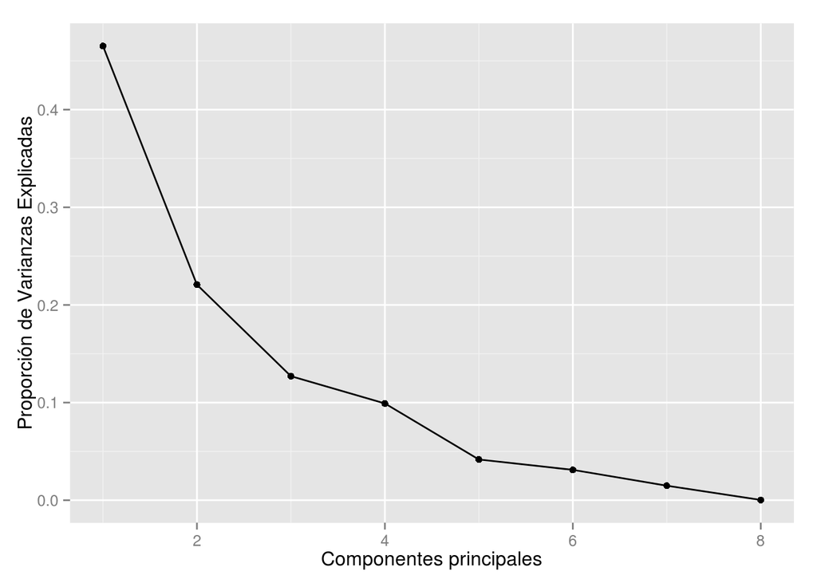

```r
data.pca.var <- data.pca$sdev^2
data.pca.pve <- data.pca.var/sum(data.pca.var)

qplot(seq_along(data.pca.pve),
      data.pca.pve,
      geom = c("point", "path"),
      xlab = "Componentes principales",
      ylab = "Proporción de Varianzas Explicadas")
```

Y la proporción acumulada de varianza explicada por cada componente principal.

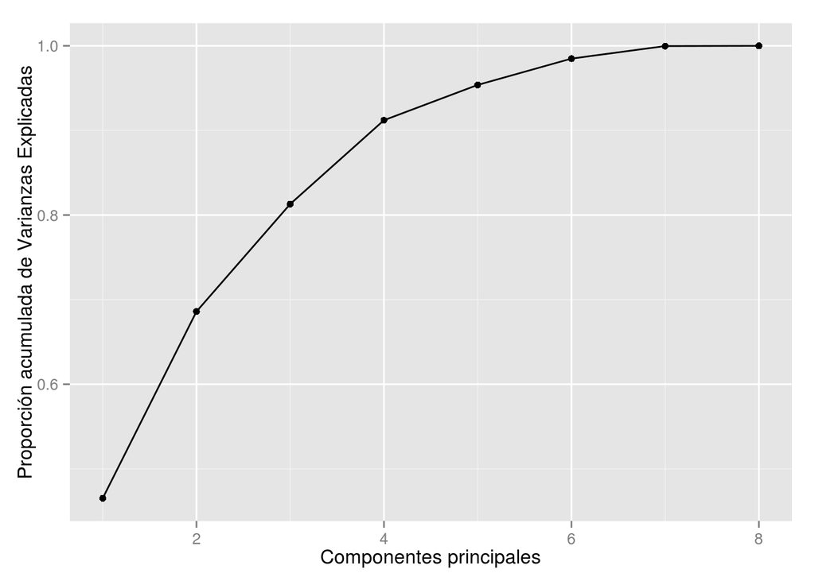

```r
qplot(seq_along(data.pca.pve),
      cumsum(data.pca.pve),
      geom = c("point", "path"),
      xlab = "Componentes principales",
      ylab = "Proporción acumulada de Varianzas Explicadas")
```

Observamos que con 4 componentes principales explicamos más del 90% de los datos.

Procedemos a generar los clústeres mediante *k-means*:

```r
data.pca <- data.frame(data.pca$x[, 1:4])
```

Haciendo uso de la función *NbClust* del paquete **NbClust**, intentamos determinar el mejor número de clústeres estudiando la distancia Euclídea.

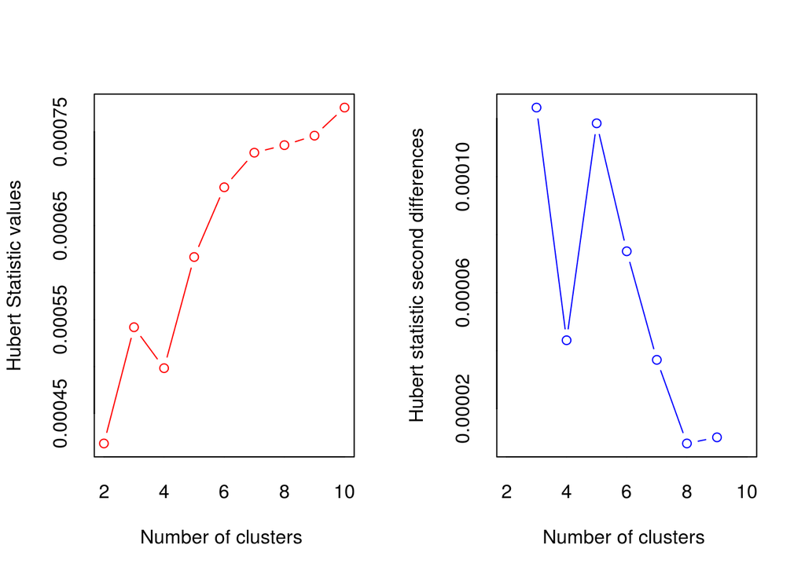

```
## *** : The Hubert index is a graphical method of determining the number of clusters.
##                 In the plot of Hubert index, we seek a significant knee that corresponds to a
##                 significant increase of the value of the measure i.e the significant peak in Hubert
##                 index second differences plot.
##
```

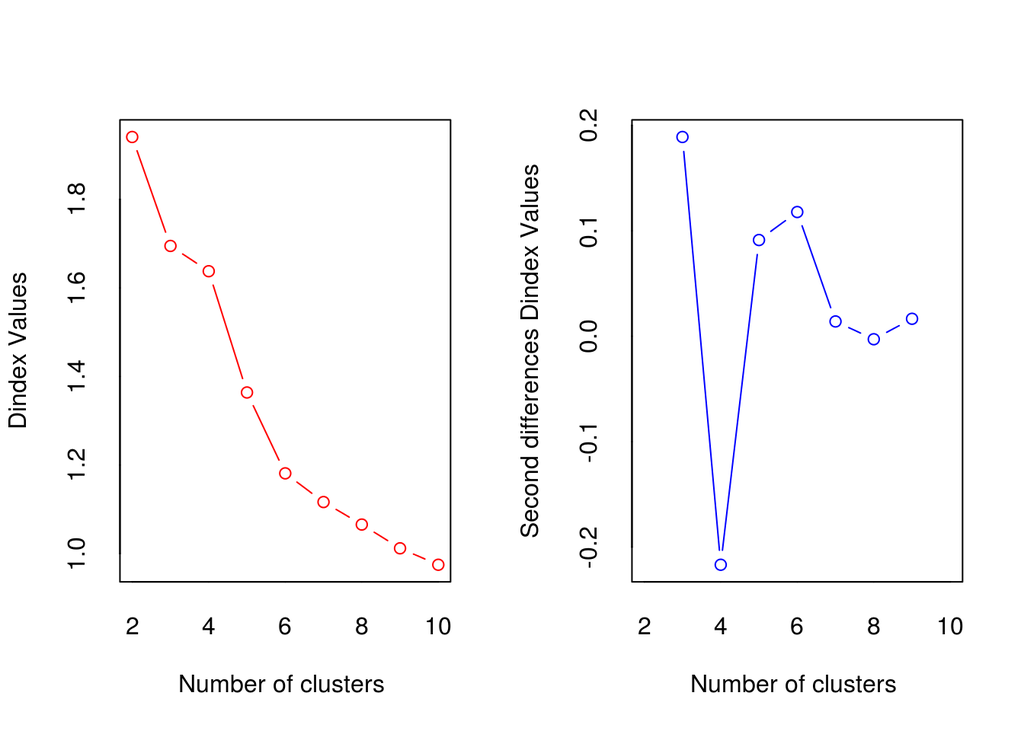

```
## *** : The D index is a graphical method of determining the number of clusters.
##                 In the plot of D index, we seek a significant knee (the significant peak in Dindex
##                 second differences plot) that corresponds to a significant increase of the value of
##                 the measure.
##
## * Among all indices:
## * 4 proposed 2 as the best number of clusters
## * 4 proposed 3 as the best number of clusters
## * 2 proposed 4 as the best number of clusters
## * 2 proposed 5 as the best number of clusters
## * 4 proposed 6 as the best number of clusters
## * 3 proposed 7 as the best number of clusters
## * 1 proposed 9 as the best number of clusters
## * 3 proposed 10 as the best number of clusters
##
##                    ***** Conclusion *****
##
## * According to the majority rule, the best number of clusters is  2
##
##
```

```r
nc <- NbClust(data.pca, min.nc = 2, max.nc = 10,
              distance = "euclidean", method = "kmeans")
```

```r
table(nc$Best.nc[1,])
```

```
##
##  0  1  2  3  4  5  6  7  9 10
##  2  1  4  4  2  2  4  3  1  3
```

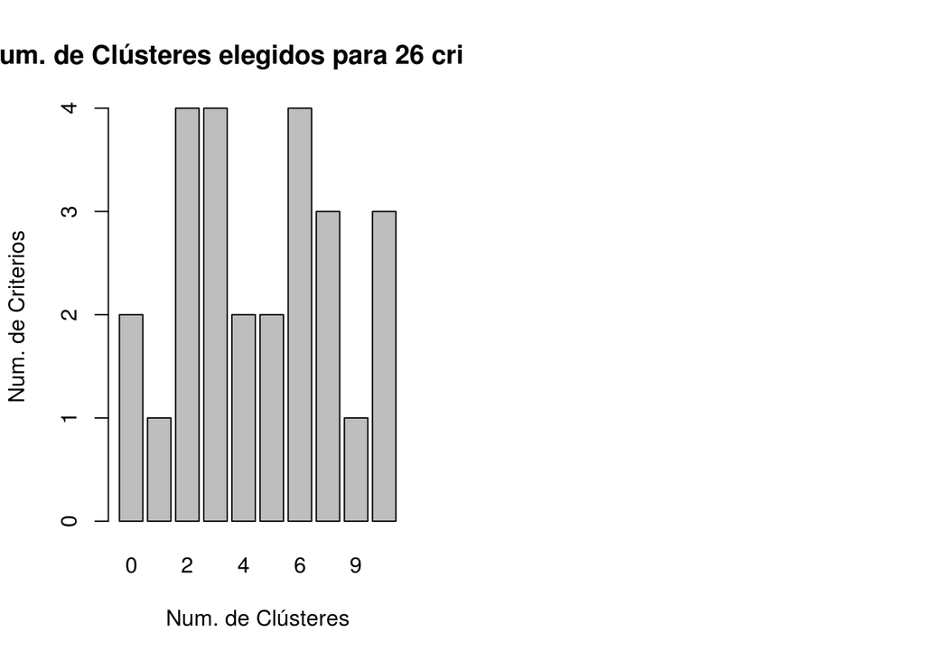

```r
barplot(table(nc$Best.n[1,]),
        xlab="Num. de Clústeres", ylab="Num. de Criterios",
        main="Num. de Clústeres elegidos para 26 criterios")
```

Parece que en este caso tenemos un empate entre el número de clústeres que mejor se adaptan a nuestro *dataset*. Veamos para cada opción las tablas agregadas y el peso de cada componente principal en el clúster:

- Para **2** clústeres:

```r
fit.km2 <- kmeans(data.pca, 2, nstart = 25)
aggregate(data.pca, by=list(cluster=fit.km2$cluster), mean)
```

```
##   cluster       PC1         PC2        PC3        PC4
## 1       1 -1.538264  0.01467301  0.0917966  0.2480828
## 2       2  1.744897 -0.01664401 -0.1041275 -0.2814073
```

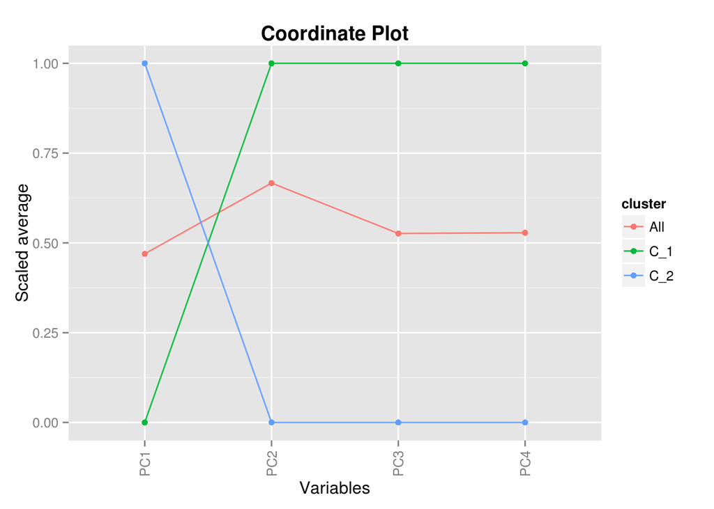

```r
plot_clus_coord(fit.km2, data.pca)
```

- Para **3** clústeres:

```r
fit.km3 <- kmeans(data.pca, 3, nstart = 25)
aggregate(data.pca, by=list(cluster=fit.km3$cluster), mean)
```

```
##   cluster        PC1        PC2        PC3        PC4
## 1       1 -2.6375638 -0.8729488 -0.2525169 -0.5962573
## 2       2 -0.4961838  0.8128306  0.1572047  0.6182478
## 3       3  2.0122556 -0.3556737 -0.0214054 -0.3088714
```

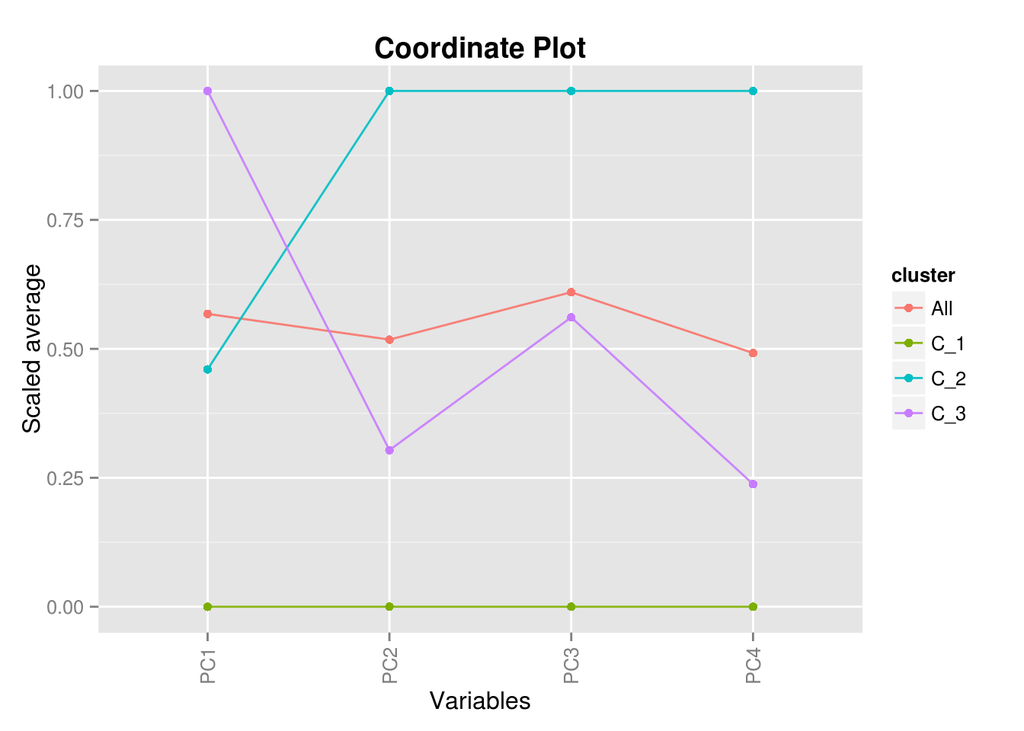

```r
plot_clus_coord(fit.km3, data.pca)
```

- Para **6** clústeres:

```r
fit.km6 <- kmeans(data.pca, 6, nstart = 25)
aggregate(data.pca, by=list(cluster=fit.km6$cluster), mean)
```

```
##   cluster        PC1        PC2         PC3        PC4
## 1       1 -0.4742375 -0.4143138  0.83001749  1.4282601
## 2       2  2.0859123 -0.5611737  0.05046181 -0.3387550
## 3       3 -2.3688084  0.3907709  0.73979946 -0.6697250
## 4       4 -0.8735716  2.5490253 -0.78528781  0.2124147
## 5       5  0.9122716  1.2215434 -0.43934362 -0.2774610
## 6       6 -2.6393333 -1.9787717 -1.40394414 -0.2624291
```

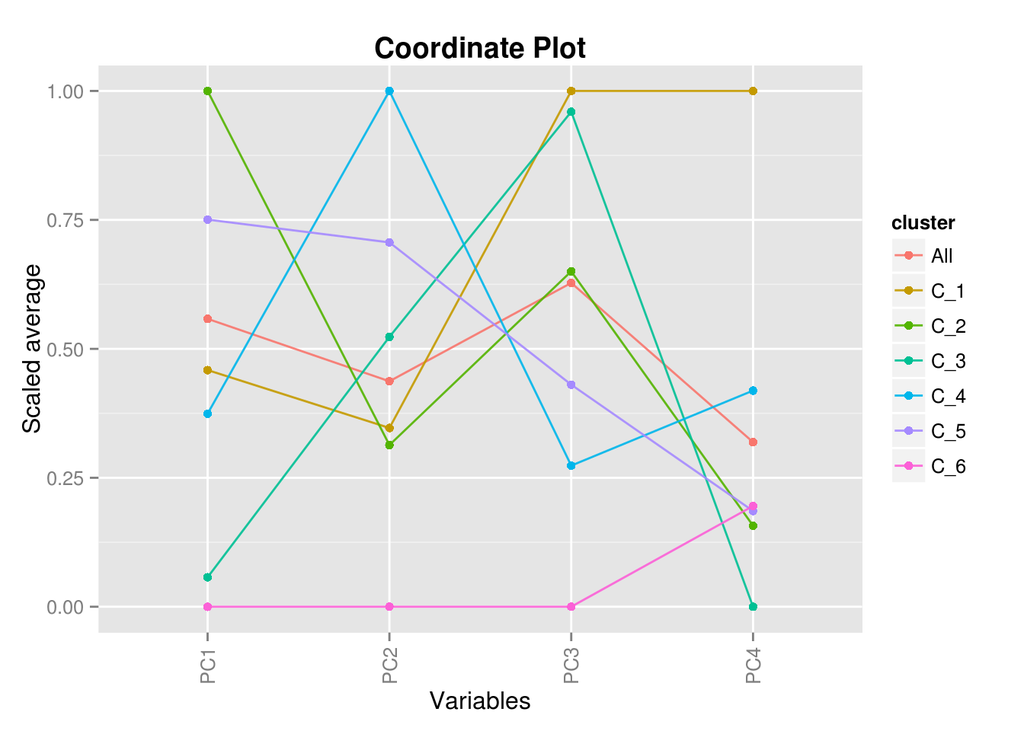

```r
plot_clus_coord(fit.km6, data.pca)
```